# Data visualisation and some preprocessing

The goal with this notebook is to visualise the data and better understand it.

```python
import pandas as pd
import numpy as np
import matplotlib.pyplot as plt


import matplotlib as mpl
import matplotlib.pyplot as plt
import matplotlib.pylab as pylab
import seaborn as sns

%matplotlib inline
mpl.style.use( 'ggplot' )
sns.set_style( 'white' )
pylab.rcParams[ 'figure.figsize' ] = 8 , 6
```

```python
! ls
```

```
data		ouput2.csv	   visualisng_preprocessed_data.ipynb
data.csv	ouput.csv	   web_download_prepare.ipynb
extracted_data	sound_feature_2.R
extract.yaml	sound_feature.R
```

```python
# Read file, first column is th index
df = pd.read_csv("ouput.csv",index_col=0)
df
```

|  | file | label | language | age_range | dialect | duration | meanfreq | sd | median | Q25 | ... | mode | centroid | peakf | meanfun | minfun | maxfun | meandom | mindom | maxdom | dfrange |
| --- | --- | --- | --- | --- | --- | --- | --- | --- | --- | --- | --- | --- | --- | --- | --- | --- | --- | --- | --- | --- | --- |
| 1 | /home/niklas_sven_hansson/test/extracted_data/... | Male | EN | Adult | British English | 4.181375 | 0.126120 | 0.089531 | 0.126946 | 0.031617 | ... | 0.008862 | 0.126120 | 0 | 0.139242 | 0.062992 | 0.275862 | 0.075543 | 0.00000 | 0.71875 | 0.71875 |
| 2 | /home/niklas_sven_hansson/test/extracted_data/... | Male | EN | Adult | British English | 4.224000 | 0.123339 | 0.087334 | 0.128027 | 0.033192 | ... | 0.009958 | 0.123339 | 0 | 0.136481 | 0.062992 | 0.275862 | 0.094308 | 0.00000 | 0.62500 | 0.62500 |
| 3 | /home/niklas_sven_hansson/test/extracted_data/... | Male | EN | Adult | British English | 6.272000 | 0.119344 | 0.086107 | 0.121413 | 0.032707 | ... | 0.006063 | 0.119344 | 0 | 0.141187 | 0.063241 | 0.275862 | 0.176662 | 0.00000 | 4.37500 | 4.37500 |
| 4 | /home/niklas_sven_hansson/test/extracted_data/... | Male | EN | Adult | British English | 4.181375 | 0.133555 | 0.085755 | 0.122874 | 0.060120 | ... | 0.119521 | 0.133555 | 0 | 0.124622 | 0.062745 | 0.275862 | 0.079117 | 0.00000 | 0.68750 | 0.68750 |
| 5 | /home/niklas_sven_hansson/test/extracted_data/... | Male | EN | Adult | British English | 3.242688 | 0.123961 | 0.082045 | 0.123002 | 0.050066 | ... | 0.127329 | 0.123961 | 0 | 0.131050 | 0.062745 | 0.275862 | 0.055990 | 0.00000 | 0.53125 | 0.53125 |
| 6 | /home/niklas_sven_hansson/test/extracted_data/... | Male | EN | Adult | British English | 5.930688 | 0.126606 | 0.086145 | 0.128101 | 0.039494 | ... | 0.008439 | 0.126606 | 0 | 0.140516 | 0.062745 | 0.275862 | 0.075970 | 0.00000 | 2.59375 | 2.59375 |
| 7 | /home/niklas_sven_hansson/test/extracted_data/... | Male | EN | Adult | British English | 3.456000 | 0.100986 | 0.082449 | 0.102319 | 0.023188 | ... | 0.006377 | 0.100986 | 0 | 0.139884 | 0.062992 | 0.271186 | 0.076823 | 0.00000 | 0.40625 | 0.40625 |
| 8 | /home/niklas_sven_hansson/test/extracted_data/... | Male | EN | Adult | British English | 4.736000 | 0.107251 | 0.082264 | 0.111789 | 0.028528 | ... | 0.006551 | 0.107251 | 0 | 0.136327 | 0.063241 | 0.275862 | 0.130659 | 0.00000 | 4.25000 | 4.25000 |
| 9 | /home/niklas_sven_hansson/test/extracted_data/... | Male | EN | Adult | British English | 4.650688 | 0.115765 | 0.087045 | 0.117510 | 0.027978 | ... | 0.007533 | 0.115765 | 0 | 0.135586 | 0.062745 | 0.275862 | 0.144593 | 0.00000 | 4.53125 | 4.53125 |
| 10 | /home/niklas_sven_hansson/test/extracted_data/... | Male | EN | Adult | British English | 6.229375 | 0.138360 | 0.083537 | 0.134137 | 0.084337 | ... | 0.130120 | 0.138360 | 0 | 0.136774 | 0.062745 | 0.275862 | 0.096794 | 0.00000 | 0.46875 | 0.46875 |
| 11 | /home/niklas_sven_hansson/test/extracted_data/... | Male | EN | Adult | British English | 2.730688 | 0.160598 | 0.079875 | 0.165138 | 0.107523 | ... | 0.000000 | 0.160598 | 0 | 0.131653 | 0.062992 | 0.275862 | 0.466033 | 0.00000 | 4.81250 | 4.81250 |
| 12 | /home/niklas_sven_hansson/test/extracted_data/... | Male | EN | Adult | British English | 4.693375 | 0.158842 | 0.081447 | 0.164631 | 0.105773 | ... | 0.000000 | 0.158842 | 0 | 0.129421 | 0.064000 | 0.275862 | 0.246951 | 0.00000 | 3.78125 | 3.78125 |
| 13 | /home/niklas_sven_hansson/test/extracted_data/... | Male | EN | Adult | British English | 4.352000 | 0.161181 | 0.084804 | 0.161512 | 0.098932 | ... | 0.000000 | 0.161181 | 0 | 0.128578 | 0.062745 | 0.262295 | 0.381173 | 0.00000 | 4.34375 | 4.34375 |
| 14 | /home/niklas_sven_hansson/test/extracted_data/... | Male | EN | Adult | British English | 3.413375 | 0.159507 | 0.078959 | 0.174633 | 0.099790 | ... | 0.000000 | 0.159507 | 0 | 0.137178 | 0.063745 | 0.275862 | 0.285218 | 0.00000 | 2.68750 | 2.68750 |
| 15 | /home/niklas_sven_hansson/test/extracted_data/... | Male | EN | Adult | British English | 5.034688 | 0.158488 | 0.072633 | 0.177187 | 0.102614 | ... | 0.000000 | 0.158488 | 0 | 0.119149 | 0.062745 | 0.275862 | 0.360923 | 0.00000 | 6.90625 | 6.90625 |
| 16 | /home/niklas_sven_hansson/test/extracted_data/... | Male | EN | Adult | British English | 5.205375 | 0.164685 | 0.078718 | 0.190192 | 0.109615 | ... | 0.000000 | 0.164685 | 0 | 0.138296 | 0.063492 | 0.275862 | 0.295000 | 0.00000 | 4.18750 | 4.18750 |
| 17 | /home/niklas_sven_hansson/test/extracted_data/... | Male | EN | Adult | British English | 3.072000 | 0.156708 | 0.071387 | 0.164610 | 0.099418 | ... | 0.000000 | 0.156708 | 0 | 0.126348 | 0.062745 | 0.275862 | 0.283245 | 0.00000 | 2.78125 | 2.78125 |
| 18 | /home/niklas_sven_hansson/test/extracted_data/... | Male | EN | Adult | British English | 4.437375 | 0.164905 | 0.075001 | 0.187945 | 0.110556 | ... | 0.000000 | 0.164905 | 0 | 0.129555 | 0.064000 | 0.275862 | 0.274829 | 0.00000 | 4.50000 | 4.50000 |
| 19 | /home/niklas_sven_hansson/test/extracted_data/... | Male | EN | Adult | British English | 3.669375 | 0.158869 | 0.073950 | 0.182300 | 0.103977 | ... | 0.102885 | 0.158869 | 0 | 0.130608 | 0.063241 | 0.275862 | 0.352865 | 0.00000 | 2.87500 | 2.87500 |
| 20 | /home/niklas_sven_hansson/test/extracted_data/... | Male | EN | Adult | British English | 3.840000 | 0.158082 | 0.076217 | 0.180149 | 0.103240 | ... | 0.000000 | 0.158082 | 0 | 0.130541 | 0.063241 | 0.262295 | 0.457386 | 0.00000 | 4.84375 | 4.84375 |
| 21 | /home/niklas_sven_hansson/test/extracted_data/... | Male | EN | Youth | European English | 3.250000 | 0.174163 | 0.064990 | 0.146623 | 0.118592 | ... | 0.123520 | 0.174163 | 0 | 0.120915 | 0.064257 | 0.275862 | 0.388221 | 0.00000 | 3.21875 | 3.21875 |
| 22 | /home/niklas_sven_hansson/test/extracted_data/... | Male | EN | Youth | European English | 5.875000 | 0.162325 | 0.068094 | 0.137445 | 0.106277 | ... | 0.129611 | 0.162325 | 0 | 0.117968 | 0.062745 | 0.271186 | 0.508961 | 0.00000 | 6.68750 | 6.68750 |
| 23 | /home/niklas_sven_hansson/test/extracted_data/... | Male | EN | Youth | European English | 3.250000 | 0.183573 | 0.064321 | 0.214389 | 0.124752 | ... | 0.126601 | 0.183573 | 0 | 0.125548 | 0.062745 | 0.271186 | 0.302989 | 0.00000 | 0.93750 | 0.93750 |
| 24 | /home/niklas_sven_hansson/test/extracted_data/... | Male | EN | Youth | European English | 5.500000 | 0.180368 | 0.069135 | 0.151189 | 0.123717 | ... | 0.138090 | 0.180368 | 0 | 0.121029 | 0.063745 | 0.271186 | 0.363986 | 0.00000 | 3.34375 | 3.34375 |
| 25 | /home/niklas_sven_hansson/test/extracted_data/... | Male | EN | Youth | European English | 5.000000 | 0.172424 | 0.067021 | 0.158113 | 0.124289 | ... | 0.273996 | 0.172424 | 0 | 0.120318 | 0.063492 | 0.271186 | 0.355172 | 0.00000 | 4.84375 | 4.84375 |
| 26 | /home/niklas_sven_hansson/test/extracted_data/... | Male | EN | Youth | European English | 3.875000 | 0.174322 | 0.066596 | 0.147491 | 0.128118 | ... | 0.129410 | 0.174322 | 0 | 0.116588 | 0.062992 | 0.275862 | 0.294850 | 0.00000 | 2.37500 | 2.37500 |
| 27 | /home/niklas_sven_hansson/test/extracted_data/... | Male | EN | Youth | European English | 3.750000 | 0.166879 | 0.067774 | 0.143337 | 0.115310 | ... | 0.129724 | 0.166879 | 0 | 0.123866 | 0.063241 | 0.275862 | 0.384046 | 0.00000 | 3.71875 | 3.71875 |
| 28 | /home/niklas_sven_hansson/test/extracted_data/... | Male | EN | Youth | European English | 3.250000 | 0.168330 | 0.066012 | 0.145083 | 0.126601 | ... | 0.143850 | 0.168330 | 0 | 0.121967 | 0.062745 | 0.266667 | 0.321909 | 0.00000 | 1.25000 | 1.25000 |
| 29 | /home/niklas_sven_hansson/test/extracted_data/... | Male | EN | Youth | European English | 4.000000 | 0.171977 | 0.067887 | 0.149884 | 0.120858 | ... | 0.129366 | 0.171977 | 0 | 0.121612 | 0.062745 | 0.275862 | 0.621711 | 0.00000 | 3.25000 | 3.25000 |
| 30 | /home/niklas_sven_hansson/test/extracted_data/... | Male | EN | Youth | European English | 3.750000 | 0.166779 | 0.066869 | 0.153746 | 0.110238 | ... | 0.128923 | 0.166779 | 0 | 0.116525 | 0.064777 | 0.271186 | 0.389205 | 0.00000 | 1.09375 | 1.09375 |
| ... | ... | ... | ... | ... | ... | ... | ... | ... | ... | ... | ... | ... | ... | ... | ... | ... | ... | ... | ... | ... | ... |
| 82864 | /home/niklas_sven_hansson/test/extracted_data/... | Male | EN | Adult | American English | 3.625000 | 0.170593 | 0.051868 | 0.163471 | 0.143037 | ... | 0.059921 | 0.170593 | 0 | 0.140963 | 0.063241 | 0.262295 | 1.100893 | 0.00000 | 5.56250 | 5.56250 |
| 82865 | /home/niklas_sven_hansson/test/extracted_data/... | Male | EN | Adult | American English | 3.000000 | 0.166247 | 0.057675 | 0.151180 | 0.140167 | ... | 0.060072 | 0.166247 | 0 | 0.124990 | 0.062992 | 0.275862 | 1.132622 | 0.00000 | 5.25000 | 5.25000 |
| 82866 | /home/niklas_sven_hansson/test/extracted_data/... | Male | EN | Adult | American English | 3.625000 | 0.169609 | 0.060682 | 0.149941 | 0.138619 | ... | 0.059921 | 0.169609 | 0 | 0.129208 | 0.063492 | 0.266667 | 0.782589 | 0.00000 | 6.18750 | 6.18750 |
| 82867 | /home/niklas_sven_hansson/test/extracted_data/... | Male | EN | Adult | American English | 4.750000 | 0.172013 | 0.054246 | 0.163281 | 0.143687 | ... | 0.060045 | 0.172013 | 0 | 0.141863 | 0.062992 | 0.275862 | 1.210165 | 0.00000 | 6.96875 | 6.96875 |
| 82868 | /home/niklas_sven_hansson/test/extracted_data/... | Male | EN | Adult | American English | 5.375000 | 0.173980 | 0.058514 | 0.154521 | 0.139069 | ... | 0.059947 | 0.173980 | 0 | 0.129098 | 0.062745 | 0.275862 | 1.231016 | 0.00000 | 6.34375 | 6.34375 |
| 82869 | /home/niklas_sven_hansson/test/extracted_data/... | Male | EN | Adult | American English | 4.000000 | 0.168575 | 0.054548 | 0.155889 | 0.141626 | ... | 0.060054 | 0.168575 | 0 | 0.141394 | 0.063492 | 0.275862 | 1.058594 | 0.00000 | 4.75000 | 4.75000 |
| 82870 | /home/niklas_sven_hansson/test/extracted_data/... | Male | EN | Adult | American English | 5.625000 | 0.172618 | 0.056991 | 0.157433 | 0.144803 | ... | 0.059949 | 0.172618 | 0 | 0.134692 | 0.062745 | 0.258065 | 1.273840 | 0.00000 | 6.28125 | 6.28125 |
| 82871 | /home/niklas_sven_hansson/test/extracted_data/... | Male | EN | Adult | American English | 2.750000 | 0.186061 | 0.050475 | 0.180962 | 0.154382 | ... | 0.200624 | 0.186061 | 0 | 0.153202 | 0.063745 | 0.262295 | 0.666331 | 0.06250 | 5.31250 | 5.25000 |
| 82872 | /home/niklas_sven_hansson/test/extracted_data/... | Male | EN | Adult | American English | 3.375000 | 0.171204 | 0.049346 | 0.161949 | 0.144449 | ... | 0.059915 | 0.171204 | 0 | 0.138573 | 0.062992 | 0.246154 | 0.739773 | 0.12500 | 6.96875 | 6.84375 |
| 82873 | /home/niklas_sven_hansson/test/extracted_data/... | Male | EN | Adult | American English | 3.750000 | 0.167766 | 0.052846 | 0.156949 | 0.140133 | ... | 0.060057 | 0.167766 | 0 | 0.136587 | 0.062745 | 0.271186 | 1.334173 | 0.00000 | 6.71875 | 6.71875 |
| 82874 | /home/niklas_sven_hansson/test/extracted_data/... | Male | EN | Adult | American English | 5.125000 | 0.223532 | 0.047401 | 0.240753 | 0.203849 | ... | 0.249930 | 0.223532 | 0 | 0.135529 | 0.063241 | 0.271186 | 0.812500 | 0.21875 | 5.40625 | 5.18750 |
| 82875 | /home/niklas_sven_hansson/test/extracted_data/... | Male | EN | Adult | American English | 6.000000 | 0.217257 | 0.044581 | 0.229136 | 0.203621 | ... | 0.245313 | 0.217257 | 0 | 0.135445 | 0.062745 | 0.266667 | 0.907237 | 0.00000 | 6.34375 | 6.34375 |
| 82876 | /home/niklas_sven_hansson/test/extracted_data/... | Male | EN | Adult | American English | 4.125000 | 0.220133 | 0.053061 | 0.238024 | 0.185858 | ... | 0.276118 | 0.220133 | 0 | 0.145934 | 0.064777 | 0.271186 | 0.979403 | 0.09375 | 5.96875 | 5.87500 |
| 82877 | /home/niklas_sven_hansson/test/extracted_data/... | Male | EN | Adult | American English | 5.125000 | 0.216068 | 0.051442 | 0.230404 | 0.167531 | ... | 0.245635 | 0.216068 | 0 | 0.137724 | 0.063241 | 0.275862 | 1.046402 | 0.00000 | 4.93750 | 4.93750 |
| 82878 | /home/niklas_sven_hansson/test/extracted_data/... | Male | EN | Adult | American English | 6.375000 | 0.221883 | 0.049964 | 0.238879 | 0.206390 | ... | 0.237780 | 0.221883 | 0 | 0.133398 | 0.063745 | 0.275862 | 1.061916 | 0.00000 | 6.59375 | 6.59375 |
| 82879 | /home/niklas_sven_hansson/test/extracted_data/... | Male | EN | Adult | American English | 4.875000 | 0.217289 | 0.046167 | 0.227449 | 0.206100 | ... | 0.225601 | 0.217289 | 0 | 0.144472 | 0.063745 | 0.275862 | 1.191636 | 0.00000 | 5.40625 | 5.40625 |
| 82880 | /home/niklas_sven_hansson/test/extracted_data/... | Male | EN | Adult | American English | 6.000000 | 0.215099 | 0.051031 | 0.226135 | 0.171602 | ... | 0.222132 | 0.215099 | 0 | 0.142708 | 0.062745 | 0.275862 | 1.336634 | 0.00000 | 5.25000 | 5.25000 |
| 82881 | /home/niklas_sven_hansson/test/extracted_data/... | Male | EN | Adult | American English | 5.750000 | 0.222745 | 0.048840 | 0.238931 | 0.207955 | ... | 0.245022 | 0.222745 | 0 | 0.140531 | 0.062745 | 0.275862 | 0.841954 | 0.00000 | 4.71875 | 4.71875 |
| 82882 | /home/niklas_sven_hansson/test/extracted_data/... | Male | EN | Adult | American English | 5.625000 | 0.222224 | 0.049086 | 0.239619 | 0.198170 | ... | 0.262745 | 0.222224 | 0 | 0.125758 | 0.062745 | 0.275862 | 0.908654 | 0.00000 | 6.84375 | 6.84375 |
| 82883 | /home/niklas_sven_hansson/test/extracted_data/... | Male | EN | Adult | American English | 5.750000 | 0.218876 | 0.047151 | 0.235625 | 0.201516 | ... | 0.241019 | 0.218876 | 0 | 0.137437 | 0.064516 | 0.250000 | 0.576069 | 0.18750 | 4.09375 | 3.90625 |
| 82884 | /home/niklas_sven_hansson/test/extracted_data/... | Male | EN | Youth | American English | 6.510438 | 0.115260 | 0.085633 | 0.147150 | 0.015222 | ... | 0.000000 | 0.115260 | 0 | 0.135428 | 0.062745 | 0.275862 | 0.002463 | 0.00000 | 0.50000 | 0.50000 |
| 82885 | /home/niklas_sven_hansson/test/extracted_data/... | Male | EN | Youth | American English | 5.729188 | 0.117414 | 0.087277 | 0.150917 | 0.020262 | ... | 0.000000 | 0.117414 | 0 | 0.135125 | 0.062745 | 0.275862 | 0.005587 | 0.00000 | 1.00000 | 1.00000 |
| 82886 | /home/niklas_sven_hansson/test/extracted_data/... | Male | EN | Youth | American English | 5.208312 | 0.097889 | 0.088290 | 0.079753 | 0.000192 | ... | 0.000000 | 0.097889 | 0 | 0.135951 | 0.062745 | 0.275862 | 0.042245 | 0.00000 | 5.09375 | 5.09375 |
| 82887 | /home/niklas_sven_hansson/test/extracted_data/... | Male | EN | Youth | American English | 5.729188 | 0.126069 | 0.088951 | 0.157380 | 0.012926 | ... | 0.000000 | 0.126069 | 0 | 0.138099 | 0.062745 | 0.275862 | 0.000000 | 0.00000 | 0.00000 | 0.00000 |
| 82888 | /home/niklas_sven_hansson/test/extracted_data/... | Male | EN | Youth | American English | 5.598937 | 0.110702 | 0.085629 | 0.115326 | 0.030754 | ... | 0.000000 | 0.110702 | 0 | 0.136086 | 0.062745 | 0.275862 | 0.000000 | 0.00000 | 0.00000 | 0.00000 |
| 82889 | /home/niklas_sven_hansson/test/extracted_data/... | Male | EN | Youth | American English | 5.729188 | 0.106268 | 0.090109 | 0.128908 | 0.000175 | ... | 0.000000 | 0.106268 | 0 | 0.136605 | 0.062745 | 0.275862 | 0.083450 | 0.00000 | 5.50000 | 5.50000 |
| 82890 | /home/niklas_sven_hansson/test/extracted_data/... | Male | EN | Youth | American English | 5.859375 | 0.118442 | 0.091620 | 0.148798 | 0.000171 | ... | 0.000000 | 0.118442 | 0 | 0.140777 | 0.062745 | 0.275862 | 0.003586 | 0.00000 | 0.65625 | 0.65625 |
| 82891 | /home/niklas_sven_hansson/test/extracted_data/... | Male | EN | Youth | American English | 4.036437 | 0.105521 | 0.089950 | 0.121027 | 0.000248 | ... | 0.000000 | 0.105521 | 0 | 0.145053 | 0.063492 | 0.275862 | 0.004216 | 0.00000 | 0.53125 | 0.53125 |
| 82892 | /home/niklas_sven_hansson/test/extracted_data/... | Male | EN | Youth | American English | 7.031250 | 0.114263 | 0.082767 | 0.107616 | 0.038292 | ... | 0.000000 | 0.114263 | 0 | 0.138313 | 0.062745 | 0.275862 | 0.004852 | 0.00000 | 0.96875 | 0.96875 |
| 82893 | /home/niklas_sven_hansson/test/extracted_data/... | Male | EN | Youth | American English | 5.598937 | 0.114192 | 0.093617 | 0.139821 | 0.000179 | ... | 0.000000 | 0.114192 | 0 | 0.140034 | 0.062745 | 0.275862 | 0.008261 | 0.00000 | 0.75000 | 0.75000 |

82893 rows × 26 columns

### What is the shape of data?

Comment:Correct in relation to the number of files downloaded. Also correct number fo features

```python
df.shape
```

```
(82893, 26)
```

## Check column,type and missing values.

Can see that we have some missing values, especially interesting is that we have missing values for the labels.

```python
df.info()
```

```
<class 'pandas.core.frame.DataFrame'>
Int64Index: 82893 entries, 1 to 82893
Data columns (total 26 columns):
file         82893 non-null object
label        64000 non-null object
language     59027 non-null object
age_range    58331 non-null object
dialect      67999 non-null object
duration     82893 non-null float64
meanfreq     82893 non-null float64
sd           82893 non-null float64
median       82893 non-null float64
Q25          82893 non-null float64
Q75          82893 non-null float64
IQR          82893 non-null float64
skew         82893 non-null float64
kurt         82893 non-null float64
sp.ent       82893 non-null float64
sfm          82893 non-null float64
mode         82893 non-null float64
centroid     82893 non-null float64
peakf        82893 non-null int64
meanfun      82893 non-null float64
minfun       82893 non-null float64
maxfun       82893 non-null float64
meandom      82893 non-null float64
mindom       82893 non-null float64
maxdom       82893 non-null float64
dfrange      82893 non-null float64
dtypes: float64(20), int64(1), object(5)
memory usage: 17.1+ MB
```

## Get some basitc statistics of the data

Can see that peakf is always zero(this feature was not extracted and was expected to be zero) and that mindom is dominated by zero values as well. Base on this peakfrequency will be removed.

```python
df.describe()
```

|  | duration | meanfreq | sd | median | Q25 | Q75 | IQR | skew | kurt | sp.ent | ... | mode | centroid | peakf | meanfun | minfun | maxfun | meandom | mindom | maxdom | dfrange |
| --- | --- | --- | --- | --- | --- | --- | --- | --- | --- | --- | --- | --- | --- | --- | --- | --- | --- | --- | --- | --- | --- |
| count | 82893.000000 | 82893.000000 | 82893.000000 | 82893.000000 | 82893.000000 | 82893.000000 | 82893.000000 | 82893.000000 | 82893.000000 | 82893.000000 | ... | 82893.000000 | 82893.000000 | 82893.0 | 82893.000000 | 82893.000000 | 82893.000000 | 82893.000000 | 82893.000000 | 82893.000000 | 82893.000000 |
| mean | 5.021416 | 0.163588 | 0.066942 | 0.163613 | 0.114584 | 0.218011 | 0.103427 | 5.214139 | 105.439359 | 0.914992 | ... | 0.121441 | 0.163588 | 0.0 | 0.136509 | 0.063330 | 0.273526 | 0.618498 | 0.005795 | 4.367274 | 4.361478 |
| std | 1.770119 | 0.031612 | 0.014355 | 0.041697 | 0.047313 | 0.029402 | 0.037016 | 7.694458 | 266.026102 | 0.048836 | ... | 0.086704 | 0.031612 | 0.0 | 0.018090 | 0.001993 | 0.005256 | 0.446090 | 0.029213 | 2.099036 | 2.098000 |
| min | 0.399438 | 0.010042 | 0.018363 | 0.000000 | 0.000000 | 0.000114 | 0.000114 | -0.038473 | 1.275980 | 0.187236 | ... | 0.000000 | 0.010042 | 0.0 | 0.076070 | 0.062745 | 0.148148 | 0.000000 | 0.000000 | 0.000000 | 0.000000 |
| 25% | 3.875000 | 0.145092 | 0.058606 | 0.137154 | 0.094880 | 0.204659 | 0.080224 | 1.715230 | 6.237136 | 0.899086 | ... | 0.045214 | 0.145092 | 0.0 | 0.124354 | 0.062745 | 0.271186 | 0.283482 | 0.000000 | 3.187500 | 3.187500 |
| 50% | 4.875000 | 0.166716 | 0.066974 | 0.165505 | 0.117942 | 0.222312 | 0.107825 | 2.263182 | 9.361419 | 0.924432 | ... | 0.123539 | 0.166716 | 0.0 | 0.132389 | 0.062992 | 0.275862 | 0.555707 | 0.000000 | 5.000000 | 5.000000 |
| 75% | 5.970125 | 0.185327 | 0.076881 | 0.194462 | 0.142322 | 0.238024 | 0.121755 | 3.332756 | 18.951924 | 0.942903 | ... | 0.194298 | 0.185327 | 0.0 | 0.144172 | 0.063492 | 0.275862 | 0.890203 | 0.000000 | 5.968750 | 5.937500 |
| max | 85.250000 | 0.256628 | 0.123865 | 0.269935 | 0.251605 | 0.276263 | 0.258962 | 51.242801 | 2774.534731 | 0.987639 | ... | 0.280000 | 0.256628 | 0.0 | 0.271264 | 0.271186 | 0.275862 | 4.311607 | 0.718750 | 6.968750 | 6.968750 |

8 rows × 21 columns

## Missing values

The missing values, especially for the labels, means that I will have to remove some of the observations.

```python
df.isnull().sum()
```

```
file             0
label        18893
language     23866
age_range    24562
dialect      14894
duration         0
meanfreq         0
sd               0
median           0
Q25              0
Q75              0
IQR              0
skew             0
kurt             0
sp.ent           0
sfm              0
mode             0
centroid         0
peakf            0
meanfun          0
minfun           0
maxfun           0
meandom          0
mindom           0
maxdom           0
dfrange          0
dtype: int64
```

```python
df = df.drop("peakf",axis=1)
# This feature was not extracted in R due to that it took to long to calculate after initial tests
```

## Balance of the dataset

Can see that the data set is heavily imbalanced with male being the dominant value. We can also see that the labels need to be adjusted to only include Female/Male. Some labels are in spanish and some that are in german. Will adjust the labels later to only include Female/Male

```python
df['label'].value_counts()
```

```
Male         52760
male          6837
Female        3824
unknown        193
Please         189
female         157
Masculino       10
adult           10
make            10
Weiblich        10
Name: label, dtype: int64
```

```python
procentage_female=df[(df['label']=="Female") |(df['label']=="female")].shape[0]/df[(df['label']=="Male") | (df['label']=="male") | (df['label']=="Msculino")].shape[0]
print("The procentage of femal observations is {}".format(procentage_female))
```

```
The procentage of femal observations is 0.06679866436230011
```

## Check the correlation between the continouse variables.

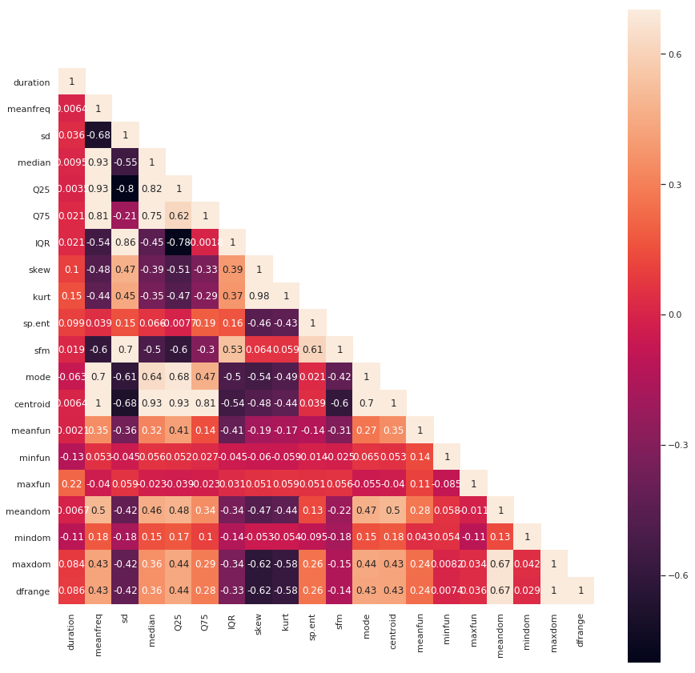

```python
cat_columns=["file","label","language","age_range","dialect"]
continues_columns = [column for column in df.columns if column not in cat_columns]
df_corr = df[continues_columns].corr()
array = np.array(df_corr)
array[np.tril_indices_from(array)] = False
fig,ax= plt.subplots()
fig.set_size_inches(15,15)
sns_plot=sns.heatmap(df_corr, mask=array,vmax=.7, square=True,annot=True)
figure = sns_plot.get_figure()
figure.savefig('feature_heat_map.png', dpi=400)
```

## Futher investigation of the text features

- Label
- Dialect
- Language
- Age range

## Label

Convert the string label to a integer. 0 represent female and 1 represent male. Some of the labels are in german and spanish. Only select the observations with a label representing Female or Male.

```python
df["label"].unique()
```

```
array(['Male', 'male', 'Female', 'female', 'Please', nan, 'unknown',
       'make', 'Masculino', 'adult', 'Weiblich'], dtype=object)
```

```python
# Masculino==male, portugise
# Weiblich==female german
label_mapping={"Male":1,"male":1,"Masculino":1,"Female":0,"female":0,"Weiblich":0}
df_selected=df.replace({'label':label_mapping})
df_selected=df_selected[(df_selected['label']==0)|(df_selected['label']==1)]
df_selected.label.unique()
```

```
array([1, 0], dtype=object)
```

## Dialect

Adjust the dialect mapping.

```python
df_selected[['dialect']]=df_selected[['dialect']].fillna("Other")
df_selected['dialect'].unique()
```

```
array(['British English', 'European English', 'American English', 'other',
       'Canadian English', 'South African', 'Indian English', 'Other',
       'Australian English', 'New Zealand', 'Northern Irish', 'unknown',
       'General American', 'Irish English', 'America English', 'New York',
       'English English', 'Mid', 'West', 'California', 'european english',
       'Español España', 'Westdeutschland', 'Please Select', 'non',
       'British Received', 'European', 'Western', 'Asian accent'],
      dtype=object)
```

```python
# map all the other,Other,nan and null to one category and then convert the rest :)
other_mapping={"other":"Other",'Please Select':"Other",'unknown':"Other",'non':"Other"}
df_selected=df_selected.replace({'dialect':other_mapping})
df_selected['dialect'].value_counts()
```

```
American English      28499
British English        8670
European English       8320
Other                  5015
Canadian English       3128
Indian English         2645
Australian English     2340
General American       1783
New Zealand             819
South African           783
New York                551
Irish English           329
Northern Irish          155
Mid                     150
California               94
British Received         70
West                     64
european english         49
English English          39
Western                  31
European                 24
Español España           10
America English          10
Asian accent             10
Westdeutschland          10
Name: dialect, dtype: int64
```

## Age_range

Fix the age range mapping.

```python
df_selected[['age_range']]=df_selected[['age_range']].fillna("Other")
df_selected['age_range'].unique()
```

```
array(['Adult', 'Youth', 'adult', 'Please', 'Senior', 'Other', 'youth',
       'Adulto', 'Erwachsener', 'unknown'], dtype=object)
```

```python
df_selected['age_range'].value_counts()
```

```
Adult          47742
Youth           7230
Other           5669
adult           1369
Senior          1318
Please           180
youth             50
unknown           20
Adulto            10
Erwachsener       10
Name: age_range, dtype: int64
```

```python
age_range_mapping={"Please":"Other","unknown":"Other","youth":"Youth","Erwachsener":"Adult","Adulto":"Adult","adult":"Adult"}
df_selected=df_selected.replace({'age_range':age_range_mapping})
df_selected['age_range'].value_counts()
```

```
Adult     49131
Youth      7280
Other      5869
Senior     1318
Name: age_range, dtype: int64
```

## Language

Check the language for the observation and select the english once

```python
df_selected['language'].value_counts()
```

```
EN    58635
Name: language, dtype: int64
```

```python
df_selected['language'].isnull().sum()
```

```
4963
```

```python
df_selected=df_selected[df_selected['language']=="EN"]
df_selected.shape
```

```
(58635, 25)
```

## How is the balance of the data now?

```python
df_selected['label'].value_counts()
```

```
1    54677
0     3958
Name: label, dtype: int64
```

# Plot the data

Initial visualisations of the data. Later on I will also make interactive plots. These where also used for data exploration

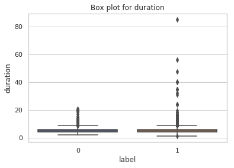

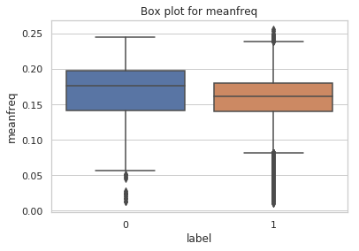

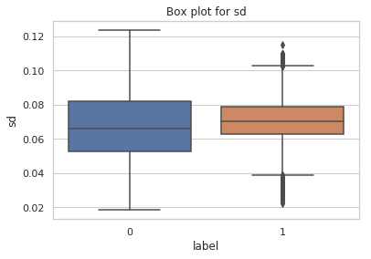

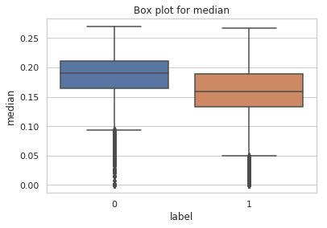

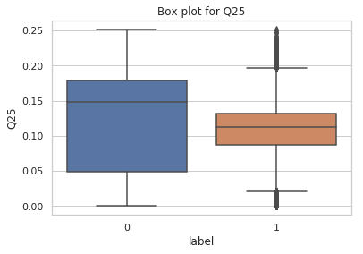

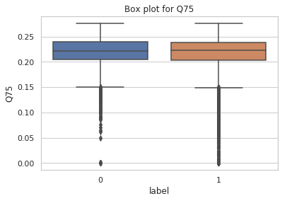

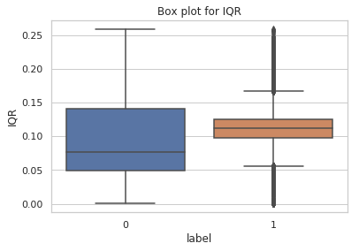

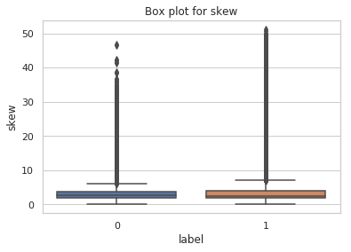

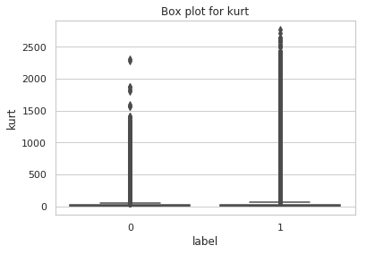

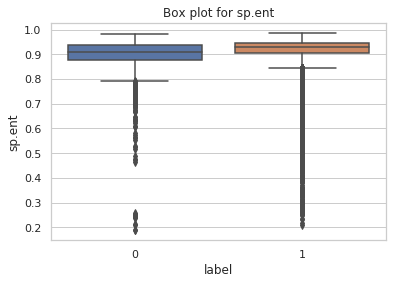

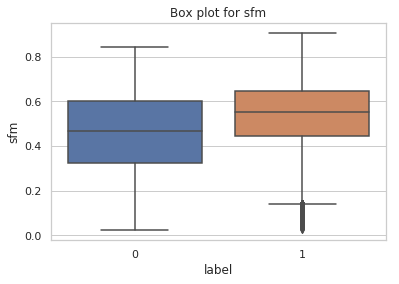

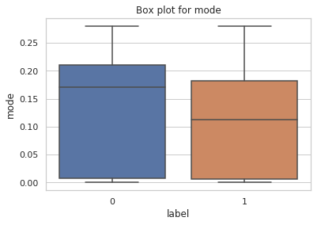

[8 more figures not shown]

```python
for n,column in enumerate(continues_columns):
    plt.figure(n)
    sns.boxplot(x="label",y=column,data=df_selected)
    plt.title("Box plot for {}".format(column))
plt.show()
```

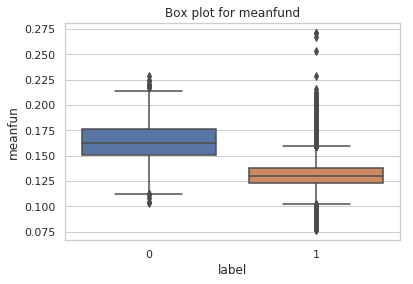

```python
plot=sns.boxplot(x="label",y="meanfun",data=df_selected)
plt.title("Box plot for meanfund")
figure = plot.get_figure()
figure.savefig('meanfund_boxplot.png', dpi=400)
```

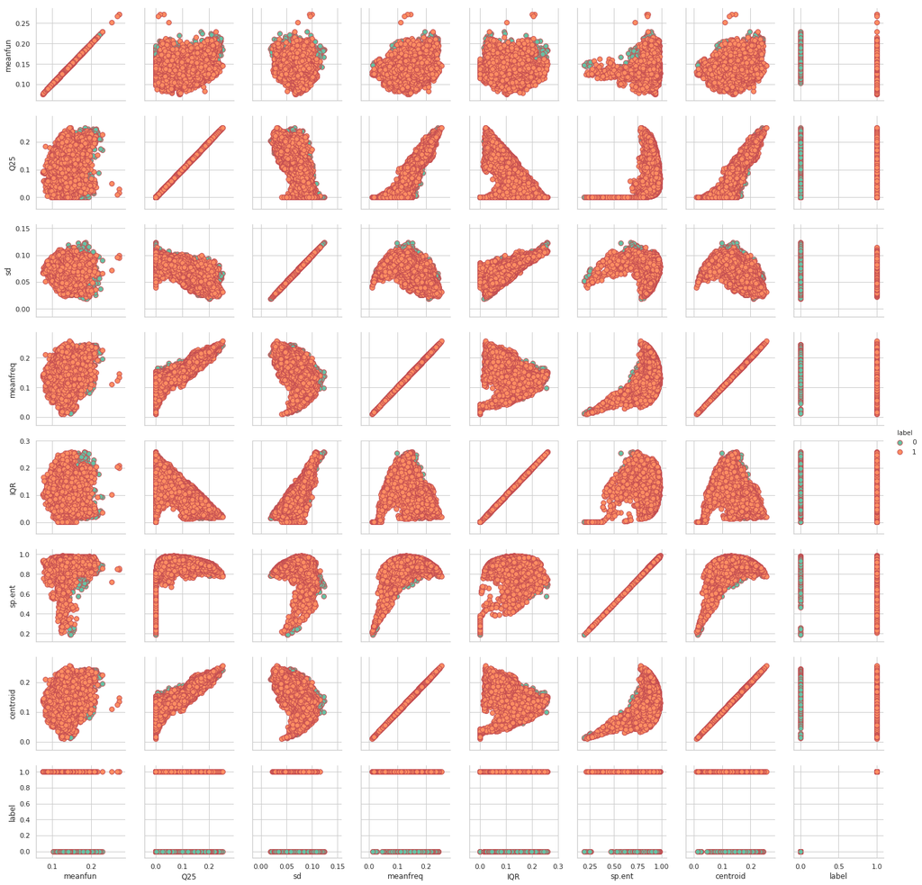

```python
g = sns.PairGrid(df_selected[["meanfun" , "Q25" , "sd" , "meanfreq" , "IQR" , "sp.ent" , "centroid", "label"]] , palette="Set2" , hue = "label")
g = g.map(plt.scatter, linewidths=1, edgecolor="r", s=60)
g = g.add_legend()
```

Form the plots above it is hard to see any seperation in the data. We can see that the correlation is perfectly correlated between centroid and meanfreq. Therefore we can later remove them to simplyfy model since they seam to carry the same information.

# Investigation of dialects

As we can see below using dialect as a feature is not a very good idea since some of the dialects only contain examples of Male voices. Thus this feature will not be used in the modelling.

```python
for dialect in df_selected['dialect'].unique():
    print(df_selected[df_selected['dialect']==dialect]['label'].value_counts())
```

```
1    6808
0     647
Name: label, dtype: int64
1    7775
0     514
Name: label, dtype: int64
1    26138
0     2121
Name: label, dtype: int64
1    4510
0     323
Name: label, dtype: int64
1    2950
0      88
Name: label, dtype: int64
1    694
0     49
Name: label, dtype: int64
1    2577
0      68
Name: label, dtype: int64
1    1730
0      98
Name: label, dtype: int64
1    758
0     30
Name: label, dtype: int64
1    319
0     10
Name: label, dtype: int64
1    10
Name: label, dtype: int64
1    212
Name: label, dtype: int64
1    39
Name: label, dtype: int64
1    64
Name: label, dtype: int64
1    10
Name: label, dtype: int64
0    10
Name: label, dtype: int64
1    39
Name: label, dtype: int64
1    24
Name: label, dtype: int64
1    10
Name: label, dtype: int64
1    10
Name: label, dtype: int64
```

# Investigation of Age Groups

The age range feature have the same problem as the dialects and some of the groups only contain male recordings. It is assumed that we will have examples in the "wild" from both genders and all age groups and thus it will not generalise well if we train on these groups where only men are present in the traning data.

```python
for dialect in df_selected['age_range'].unique():
    print(dialect)
    print(df_selected[df_selected['age_range']==dialect]['label'].value_counts())
```

```
Adult
1    45465
0     3336
Name: label, dtype: int64
Youth
1    6598
0     602
Name: label, dtype: int64
Other
1    1316
Name: label, dtype: int64
Senior
1    1298
0      20
Name: label, dtype: int64
```

## Investigation of duration

Duration is probably not a feature that will result in a model that generalises well either. Based upon the application duration could be a good feature. However in order to determine the gender from the voice I dont belive it will generalise well. This is based upon an assumption that would need further investigation for a real product.

# PCA on the data

Often hard to see natural seperation in the data over multiple variables. Usina a PCA and selecting the first two principal components offer a possible way to see if there is any clear seperation in the data.

First step is to normalise the data

```python
from sklearn import preprocessing
min_max_scaler = preprocessing.MinMaxScaler()
x_scaled = min_max_scaler.fit_transform(df_selected[continues_columns])
df_selected_scaled = pd.DataFrame(x_scaled)
```

```python
from sklearn.decomposition import PCA
pca = PCA(n_components=10)
pca_data = pca.fit_transform(df_selected_scaled)
```

```python
explained_ratio=pca.explained_variance_ratio_
print("The first component {}% of the variance".format(explained_ratio[0]))
print("The second component {}% of the variance".format(explained_ratio[1]))
```

[output not shown]

```python
df_pca = pd.DataFrame(data = pca_data,columns=['pca_comp1','pca_comp2','pca_comp3','pca_comp4','pca_comp5','pca_comp6','pca_comp7','pca_comp8','pca_comp9','pca_comp10'])
df_pca['label']=df_selected['label'].values
```

Very hard to see and seperation of the data due to that is overlayin each other. One way to try to takle this to sample the data and then look if it is overlayin in the whole data.

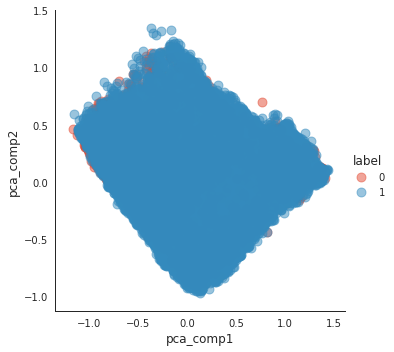

```python
sns.lmplot( x="pca_comp1", y="pca_comp2",
  data=df_pca,
  fit_reg=False,
  hue='label', # color by cluster
  legend=True,
  scatter_kws={"s": 80,'alpha': 0.5}) # specify the point size
```

Looking at the sampled plot below where 1% of the data is sampled it is hard to see any seperation of the data.

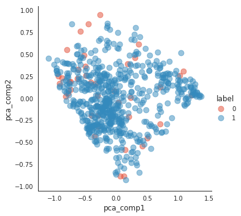

```python
df_pca_sample=df_pca.sample(frac=0.01)
sns.lmplot( x="pca_comp1", y="pca_comp2",
  data=df_pca_sample,
  fit_reg=False,
  hue='label', # color by cluster
  legend=True,
  scatter_kws={"s": 80,'alpha': 0.5}) # specify the point size
```

# Save data for modelling

```python
df_selected.to_csv("modelling_data.csv")
```